# Föreläsning 1

karl.sigfrid@stat.su.se

## Lärare på kursen

- Oscar Oelrich, examinator, doktor
- Karl Sigfrid, föreläsare, doktorand
- Anders Fredriksson, övningslärare
- Fredrik Stenkvist, övningslärare
- Sebastian Hedberg, övningslärare

Statistiska institutionen finns på plan 6 i hus 4 på Campus Albano.

Mottagningstider kommer att meddelas på Athena.

## Tre viktiga dokument

- Kursplan
  - Kursinnehåll, lärandemål, juridiskt bindande dokument.
  - Finns i mappen *Kursinformation* på Athena.
- Kursbeskrivning
  - Vad som gäller just den här terminen, allmän info, deadlines, bedömningskriterier, examination.
  - Finns i mappen *Kursinformation* på Athena.
- Läsanvisningar
  - Vad som tas upp på föreläsningar, övningar, mm.
  - Finns på kurshemsidan.

## Kursens hemsida

- Kursens hemsida är https://statisticssu.github.io/SDA1/
  - Läsanvisningar
  - Föreläsningsslides (PDF-format eller HTML-format)
  - Datorlaborationer
  - Inlämningsuppgifter
  - Länk till schema

## Athena (It’s learning)

- Läroplattformen Athena
  - Kursinformation, inklusive studieplan
  - Meddelanden, inklusive schemaändringar med kort varsel
  - Inlämning av inlämningsuppgifter
  - Chattfunktion
  - **Vi räknar med att ni har koll på meddelanden på Athena**.
  - Tips: It’s learning finns även som mobilapp.

## Kursens två delar

- Del 1 - Dataanalys och regression, 7.5 hp
- Föreläsare: Karl Sigfrid
  - Beskrivande statistik
  - Visualisering
  - Intro till regressionsanalys
  - Prediktion
  - Introduktion till programmeringsspråket R

## Kursens två delar

- Del 2 - Sannolikhetsmodeller och inferens, 7.5 hp
- Föreläsare: Oscar Oelrich
  - Sannolikhetslära
  - Sannolikhetsmodeller för dataanalys
  - Inferens - slutledning från data
  - Beslutsfattande under osäkerhet

## Examination

- Del 1 - Dataanalys och regression, 7.5 hp
  - Inlämningsuppgift, 3 hp, grupparbete, skriftlig rapport.
  - Skriftlig tentamen, 4.5 hp.
- Del 2 - Sannolikhetsmodeller och inferens, 7.5 hp
  - Inlämningsuppgift, 1.5 hp, grupparbete, skriftlig rapport.
  - Skriftlig tentamen, 6 hp

## Kurslitteratur

- De Veaux, R., Velleman, P. och Bock, D. (2021),  
  Stats: Data and Models,  
  5:e upplagan,Pearson Global Edition.
- Fysisk bok på Akademibokhandeln,  
  eller online på Adlibris och Bokus.
- En digital version finns att köpa eller hyra [här](https://nordics.pearson.com/products/stats-data-and-models-5th-global-edition-e-book?variant=42945920630933).

[figure not shown]

- Föreläsningsslides. Se under respektive föreläsning på kurswebbsidan.
- Ytterligare kompletterande material som delas ut under kursens gång.

## Inlämningsuppgifterna

- Genomförs som grupparbeten, 3 studenter i varje grupp.
- D1 och D5 är obligatoriska för gruppindelning. Ingen annan obligatorisk närvaro på kursen.
- Två tillfällen (deadlines) finns för varje inlämningsuppgift:
  - Inlämning 1
  - Inlämning 2 (komplettering)
- Om en inlämningsuppgift blir underkänd efter inlämning 1 går det att komplettera och lämna in igen vid tillfälle 2.
- Om en inlämningsuppgift blir underkänd efter inlämning 2 ges nästa inlämningstillfälle nästa termin.

## Inlämningsuppgifterna

- Samarbete inom arbetsgrupp är självklart tillåtet.
- Alla i gruppen ska bidra ungefär lika mycket till rapporten och arbetet som leder upp till rapporten.
- Samarbete mellan grupper är också tillåtet.
- Plagiering är inte tillåtet! – automatiskt textmatchningsverktyg används.
- Om ni använder information som ni har hittar i böcker eller på nätet, ange alltid källan.
- Använd gärna AI-verktyg för inlärning och för att hitta information, men lämna inte in AI-genererade svar på inlämningsuppgifterna!

## Mer om att använda AI

- Vi betraktar en AI-gerererad text som likvärdig med en text som har skrivits av någon annan person.
- Att kopiera en AI-genererad text och presentera den som sin egen är otillåtet, på samma sätt som det är otillåtet att kopiera en text ur en bok eller från ett diskussionsforum på internet.
- Om du formulerar en egen text med utgångspunkt i en AI-genererad text så bör du beskriva hur du har använt AI-verktyget.
- Du kan generera programmeringskod med ett AI-verktyg för att lära dig. All kod som lämnas i som del i en examination ska du ha skrivit själv.
- Kom ihåg att svaret från ett AI-verktyg, eller program-koden, inte alltid är korrekt. För att kunna skilja korrekta från felaktiga svar måste du du själv ha tillräckliga kunskaper.

## Salstentamen

- Två tillfällen per delkurs, se kursbeskrivningen och schema.
- Upplägg - minst 50 poäng av 100 möjliga för godkänt – kan vara räkneuppgifter och kunskapsfrågor.
- Tillåtna hjälpmedel: Formel- och Tabellsamling kommer finnas i tentasalen.
- Miniräknare utan lagrade formler tar ni med er – andra hjälpmedel är inte tillåtna.
- Om särskilda behov finns (egen lokal, extra tid, språklexikon, mm.) kontakta studievägledaren i god innan tentan (ca 3 veckor innan).
- Glöm inte att anmäla dig till tentan i god tid!

## Betyg och betygskriterier

- Inlämningsuppgifterna: Godkänd, Underkänd.
- Salstentor: A, B, C, D, E, (Fx), F.
- F och Fx är underkända betyg som kräver omtentamen.
- Går ej att komplettera vid Fx.
- Minimikrav för slutbetyg på hela kursen:
  - godkänt på båda inlämningsuppgifterna
  - minst E på båda tentorna
- För betygskriterier för respektive prov, se Kursbeskrivningen.
- Slutbetyg på hela kursen = sammanvägning av betygen på tentorna, se Kursbeskrivningen.

## Betyg och betygskriterier

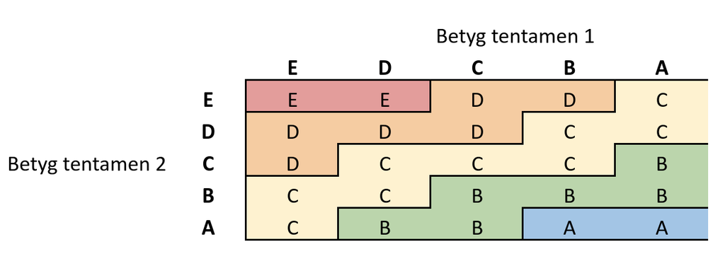

## Kursvärdering

- Enkät skickas ut efter kursen.
- Snälla, svara! Vi bryr oss verkligen om era åsikter!
- Vi sammanställer en rapport som läggs upp på Athena.

## Aktiviteterna på schemat

- Föreläsningar (F): Vi går igenom nya begrepp och metoder.
- Räkneövningar (Ö): Få hjälp att lösa räkneuppgifter.
  - Att lösa uppgifter är ofta nödvändigt för att förstå materialet.
  - Bra förberedelse inför tentan.
- Datorlaborationer (D): Få hjälp att gå igenom datorlaborationerna.
  - Bra förberedelse inför inlämningsuppgiften.

## R-hjälpen - en mapp på Athena

- Videor
  - Går igenom hur Rstudio fungerar.
  - Introducerar programmeringsspråket R.
  - Titta gärna på några av filmerna före första datorövningen. Förslagsvis video 2, och de första 5 minuterna av video 3.
- Cheat sheets
  - Sammanfattningar av de vanligaste metoderna.
  - Referensmaterial.

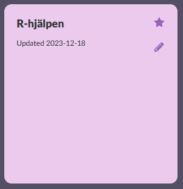

[figure not shown]

Dataanalys och Regression 7.5 hp